# Ex-Gauss for RT data

```r
library(tidyverse)
library(retimes)
library(boot)
library(broom)
library(lme4)
library(lmerTest)
library(sjPlot)

rtimes <- readRDS('rtimes_data.rds')
```

## Ex-Gaussian distribution parameters

Estimating mu, sigma, tau for each participant and condition.  
mu: mean of Gaussian distribution  
sigma: SD of Gaussian distribution  
tau: tail (greater tau -> more long RTs -> positive skew)

### Parameter distributions

`r`r sbj_params_ml %>% gather(var, value, mu:tau) %>% ggplot(aes(value, fill=interaction(congruency, shape))) + geom_density(alpha=.4) + facet_wrap(var~group, ncol=2) + theme_bw()

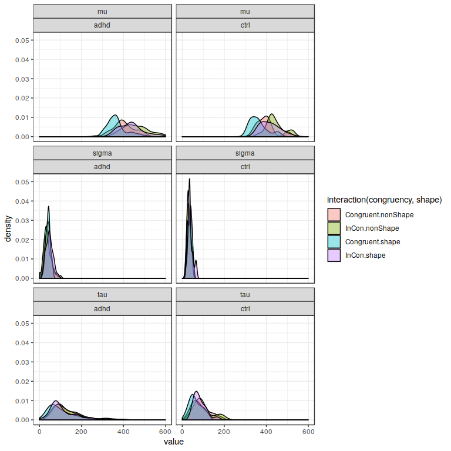

## Fitting lmer with ex-Gaussian parameters

### mu

`r`r mmu <- lmer(mu ~ group*shape*congruency + (1|shape:Subject) + (1|congruency:Subject), data=sbj_params_ml) summary(mmu)

```
Linear mixed model fit by REML. t-tests use Satterthwaite's method ['lmerModLmerTest']
Formula: mu ~ group * shape * congruency + (1 | shape:Subject) + (1 |      congruency:Subject)
   Data: sbj_params_ml

REML criterion at convergence: 2765.4

Scaled residuals:
     Min       1Q   Median       3Q      Max
-1.57974 -0.38219 -0.01074  0.34655  1.70904

Random effects:
 Groups             Name        Variance Std.Dev.
 shape:Subject      (Intercept) 2137.2   46.23
 congruency:Subject (Intercept)  180.5   13.43
 Residual                        221.8   14.89
Number of obs: 280, groups:  shape:Subject, 140; congruency:Subject, 140

Fixed effects:
                          Estimate Std. Error       df t value Pr(>|t|)
(Intercept)               410.2383     4.7648 137.3751  86.098  < 2e-16 ***
group1                     -5.6419     4.7648 137.3751  -1.184  0.23843
shape1                    -15.1060     4.5843 110.1238  -3.295  0.00132 **
congruency1               -27.9584     1.6504  53.1476 -16.940  < 2e-16 ***
group1:shape1              -0.2488     4.5843 110.1238  -0.054  0.95681
group1:congruency1          3.3232     1.6504  53.1476   2.014  0.04913 *
shape1:congruency1         -2.5326     1.0182  73.1824  -2.487  0.01515 *
group1:shape1:congruency1  -0.1424     1.0182  73.1824  -0.140  0.88919
---
Signif. codes:  0 ‘***’ 0.001 ‘**’ 0.01 ‘*’ 0.05 ‘.’ 0.1 ‘ ’ 1

Correlation of Fixed Effects:
            (Intr) group1 shape1 cngrn1 grp1:s1 grp1:c1 shp1:1
group1      0.486
shape1      0.000  0.000
congruency1 0.000  0.000  0.000
group1:shp1 0.000  0.000  0.486  0.000
grp1:cngrn1 0.000  0.000  0.000  0.486  0.000
shp1:cngrn1 0.000  0.000  0.000  0.000  0.000   0.000
grp1:shp1:1 0.000  0.000  0.000  0.000  0.000   0.000   0.486
```

`r`r plot_model(mmu, type = )[[4]]

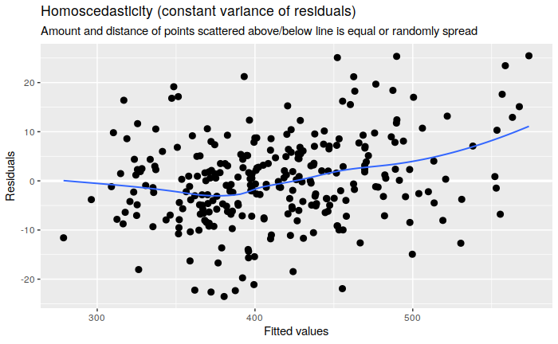

### sigma

`r`r msig <- lmer(sigma ~ group*shape*congruency + (1|shape:Subject) + (1|congruency:Subject), data=sbj_params_ml)

```
boundary (singular) fit: see ?isSingular
```

`r`r summary(msig)

```
Linear mixed model fit by REML. t-tests use Satterthwaite's method ['lmerModLmerTest']
Formula: sigma ~ group * shape * congruency + (1 | shape:Subject) + (1 |      congruency:Subject)
   Data: sbj_params_ml

REML criterion at convergence: 2251.8

Scaled residuals:
    Min      1Q  Median      3Q     Max
-3.0299 -0.4919 -0.0512  0.4333  3.3992

Random effects:
 Groups             Name        Variance Std.Dev.
 shape:Subject      (Intercept)  59.28    7.699
 congruency:Subject (Intercept)   0.00    0.000
 Residual                       145.66   12.069
Number of obs: 280, groups:  shape:Subject, 140; congruency:Subject, 140

Fixed effects:
                          Estimate Std. Error       df t value Pr(>|t|)
(Intercept)                38.3238     1.1113 136.0000  34.485  < 2e-16 ***
group1                     -3.5606     1.1113 136.0000  -3.204  0.00169 **
shape1                      2.1932     1.1113 136.0000   1.974  0.05046 .
congruency1                -0.6059     0.8251 136.0000  -0.734  0.46405
group1:shape1               0.4506     1.1113 136.0000   0.406  0.68574
group1:congruency1          0.6023     0.8251 136.0000   0.730  0.46669
shape1:congruency1         -1.9477     0.8251 136.0000  -2.360  0.01967 *
group1:shape1:congruency1   0.7499     0.8251 136.0000   0.909  0.36503
---
Signif. codes:  0 ‘***’ 0.001 ‘**’ 0.01 ‘*’ 0.05 ‘.’ 0.1 ‘ ’ 1

Correlation of Fixed Effects:
            (Intr) group1 shape1 cngrn1 grp1:s1 grp1:c1 shp1:1
group1      0.486
shape1      0.000  0.000
congruency1 0.000  0.000  0.000
group1:shp1 0.000  0.000  0.486  0.000
grp1:cngrn1 0.000  0.000  0.000  0.486  0.000
shp1:cngrn1 0.000  0.000  0.000  0.000  0.000   0.000
grp1:shp1:1 0.000  0.000  0.000  0.000  0.000   0.000   0.486
convergence code: 0
boundary (singular) fit: see ?isSingular
```

`r`r plot_model(msig, type = )[[4]]

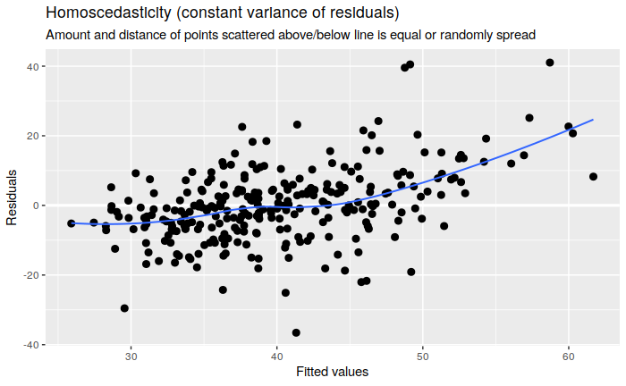

### tau

`r`r mtau <- lmer(tau ~ group*shape*congruency + (1|shape:Subject) + (1|congruency:Subject), data=sbj_params_ml) summary(mtau)

```
Linear mixed model fit by REML. t-tests use Satterthwaite's method ['lmerModLmerTest']
Formula: tau ~ group * shape * congruency + (1 | shape:Subject) + (1 |      congruency:Subject)
   Data: sbj_params_ml

REML criterion at convergence: 2877.1

Scaled residuals:
    Min      1Q  Median      3Q     Max
-2.8291 -0.3921 -0.0417  0.3307  3.6062

Random effects:
 Groups             Name        Variance Std.Dev.
 shape:Subject      (Intercept) 3250.78  57.016
 congruency:Subject (Intercept)   53.47   7.312
 Residual                        491.34  22.166
Number of obs: 280, groups:  shape:Subject, 140; congruency:Subject, 140

Fixed effects:
                          Estimate Std. Error       df t value Pr(>|t|)
(Intercept)               100.8909     5.7607 135.7926  17.514  < 2e-16 ***
group1                    -17.9255     5.7607 135.7926  -3.112  0.00227 **
shape1                    -10.0970     5.7171 126.1284  -1.766  0.07980 .
congruency1                -2.9146     1.6722  57.4817  -1.743  0.08669 .
group1:shape1               0.5789     5.7171 126.1284   0.101  0.91951
group1:congruency1         -1.6352     1.6722  57.4817  -0.978  0.33225
shape1:congruency1         -3.3232     1.5154  75.8824  -2.193  0.03138 *
group1:shape1:congruency1  -1.8720     1.5154  75.8824  -1.235  0.22054
---
Signif. codes:  0 ‘***’ 0.001 ‘**’ 0.01 ‘*’ 0.05 ‘.’ 0.1 ‘ ’ 1

Correlation of Fixed Effects:
            (Intr) group1 shape1 cngrn1 grp1:s1 grp1:c1 shp1:1
group1      0.486
shape1      0.000  0.000
congruency1 0.000  0.000  0.000
group1:shp1 0.000  0.000  0.486  0.000
grp1:cngrn1 0.000  0.000  0.000  0.486  0.000
shp1:cngrn1 0.000  0.000  0.000  0.000  0.000   0.000
grp1:shp1:1 0.000  0.000  0.000  0.000  0.000   0.000   0.486
```

`r`r plot_model(mtau, type = )[[4]]

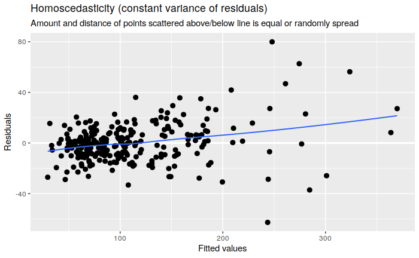

### tau (log model)

`r`r mtau.log <- lmer(log(tau) ~ group*shape*congruency + (1|shape:Subject) + (1|congruency:Subject), data=sbj_params_ml) summary(mtau.log)

```
Linear mixed model fit by REML. t-tests use Satterthwaite's method ['lmerModLmerTest']
Formula: log(tau) ~ group * shape * congruency + (1 | shape:Subject) +      (1 | congruency:Subject)
   Data: sbj_params_ml

REML criterion at convergence: 385.7

Scaled residuals:
    Min      1Q  Median      3Q     Max
-5.7897 -0.3293 -0.0047  0.3591  3.4297

Random effects:
 Groups             Name        Variance Std.Dev.
 shape:Subject      (Intercept) 0.19743  0.4443
 congruency:Subject (Intercept) 0.01701  0.1304
 Residual                       0.07206  0.2684
Number of obs: 280, groups:  shape:Subject, 140; congruency:Subject, 140

Fixed effects:
                           Estimate Std. Error        df t value Pr(>|t|)
(Intercept)                 4.47007    0.04839 136.36529  92.378  < 2e-16 ***
group1                     -0.15437    0.04839 136.36529  -3.190  0.00176 **
shape1                     -0.11848    0.04672  92.38988  -2.536  0.01289 *
congruency1                -0.03742    0.02227  42.66572  -1.680  0.10019
group1:shape1               0.00851    0.04672  92.38988   0.182  0.85586
group1:congruency1         -0.03178    0.02227  42.66572  -1.427  0.16084
shape1:congruency1         -0.05498    0.01835  82.60380  -2.996  0.00361 **
group1:shape1:congruency1  -0.03817    0.01835  82.60380  -2.080  0.04065 *
---
Signif. codes:  0 ‘***’ 0.001 ‘**’ 0.01 ‘*’ 0.05 ‘.’ 0.1 ‘ ’ 1

Correlation of Fixed Effects:
            (Intr) group1 shape1 cngrn1 grp1:s1 grp1:c1 shp1:1
group1      0.486
shape1      0.000  0.000
congruency1 0.000  0.000  0.000
group1:shp1 0.000  0.000  0.486  0.000
grp1:cngrn1 0.000  0.000  0.000  0.486  0.000
shp1:cngrn1 0.000  0.000  0.000  0.000  0.000   0.000
grp1:shp1:1 0.000  0.000  0.000  0.000  0.000   0.000   0.486
```

`r`r plot_model(mtau.log, type = )[[4]]

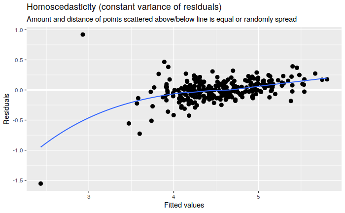

### Plot fixed effects

`r`r new_data <- expand.grid(shape = c(‘shape’, ‘nonShape’), congruency = c(‘Congruent’, ‘InCon’), group = c(‘adhd’, ‘ctrl’))

cbind(new_data, rtime = predict(mmu, newdata = new_data, re.form=NA)) %>% ggplot(aes(congruency, rtime, linetype=shape)) + geom_point() + geom_line(aes(group=shape),size=1) + facet_wrap(~group) + theme_bw() + ggtitle(values)

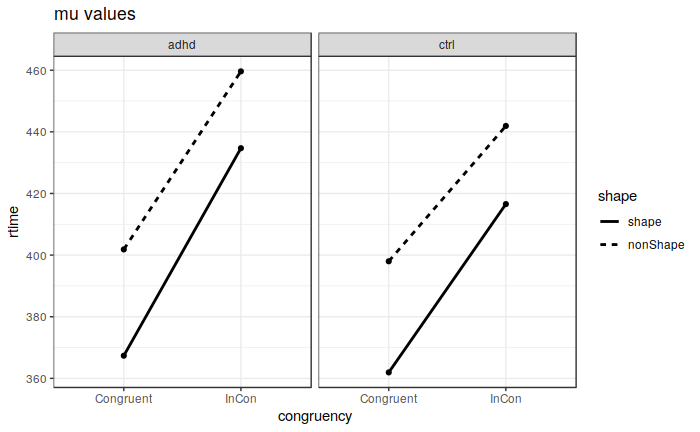

cbind(new_data, rtime = predict(msig, newdata = new_data, re.form=NA)) %>% ggplot(aes(congruency, rtime, linetype=shape)) + geom_point() + geom_line(aes(group=shape),size=1) + facet_wrap(~group) + theme_bw() + ggtitle(values)

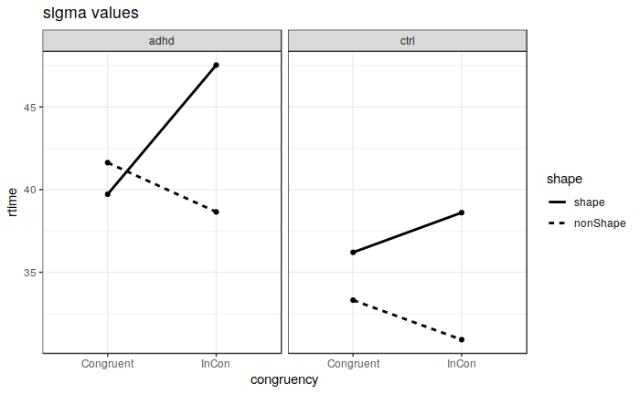

cbind(new_data, rtime = predict(mtau, newdata = new_data, re.form=NA)) %>% ggplot(aes(congruency, rtime, linetype=shape)) + geom_point() + geom_line(aes(group=shape),size=1) + facet_wrap(~group) + theme_bw() + ggtitle(values)

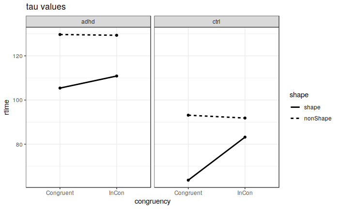

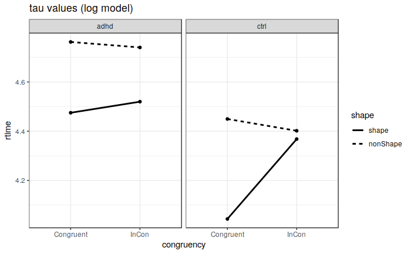

### Pairwise comparisons

Here for main effects only

```
Least Squares Means table:

                                      Estimate Std. Error    df  t value    lower    upper  Pr(>|t|)
congruencyCongruent - congruencyInCon -55.9168     3.3008  53.1 -16.9404 -62.5369 -49.2966 < 2.2e-16 ***
shapeshape - shapenonShape            -30.2120     9.1686 110.1  -3.2951 -48.3819 -12.0422  0.001324 **
groupctrl - groupadhd                 -11.2837     9.5296 137.4  -1.1841 -30.1273   7.5599  0.238428
---
Signif. codes:  0 ‘***’ 0.001 ‘**’ 0.01 ‘*’ 0.05 ‘.’ 0.1 ‘ ’ 1

  Confidence level: 95%
  Degrees of freedom method: Satterthwaite
```

`r`r difflsmeans(msig, c(, , ))

```
Least Squares Means table:

                                         Estimate  Std. Error  df t value       lower       upper Pr(>|t|)
congruencyCongruent - congruencyInCon  -1.2117311   1.6502654 136 -0.7343  -4.4752313   2.0517691 0.464052
shapeshape - shapenonShape              4.3864088   2.2226116 136  1.9735  -0.0089407   8.7817582 0.050461 .
groupctrl - groupadhd                  -7.1212821   2.2226116 136 -3.2040 -11.5166316  -2.7259327 0.001689 **
---
Signif. codes:  0 ‘***’ 0.001 ‘**’ 0.01 ‘*’ 0.05 ‘.’ 0.1 ‘ ’ 1

  Confidence level: 95%
  Degrees of freedom method: Satterthwaite
```

`r`r difflsmeans(mtau, c(, , ))

```
Least Squares Means table:

                                       Estimate Std. Error    df t value     lower     upper Pr(>|t|)
congruencyCongruent - congruencyInCon  -5.82919    3.34448  57.5 -1.7429 -12.52518   0.86679 0.086693 .
shapeshape - shapenonShape            -20.19392   11.43429 126.1 -1.7661 -42.82182   2.43399 0.079801 .
groupctrl - groupadhd                 -35.85093   11.52139 135.8 -3.1117 -58.63548 -13.06637 0.002268 **
---
Signif. codes:  0 ‘***’ 0.001 ‘**’ 0.01 ‘*’ 0.05 ‘.’ 0.1 ‘ ’ 1

  Confidence level: 95%
  Degrees of freedom method: Satterthwaite
```

`r`r difflsmeans(mtau.log, c(, , ))

```
Least Squares Means table:

                                       Estimate Std. Error    df t value     lower     upper Pr(>|t|)
congruencyCongruent - congruencyInCon -0.074836   0.044534  42.7 -1.6804 -0.164669  0.014996 0.100186
shapeshape - shapenonShape            -0.236961   0.093434  92.4 -2.5361 -0.422519 -0.051404 0.012887 *
groupctrl - groupadhd                 -0.308743   0.096778 136.4 -3.1902 -0.500123 -0.117364 0.001764 **
---
Signif. codes:  0 ‘***’ 0.001 ‘**’ 0.01 ‘*’ 0.05 ‘.’ 0.1 ‘ ’ 1

  Confidence level: 95%
  Degrees of freedom method: Satterthwaite
```

bootstrap.estimate.plot <- function(cb, model) { boot_ci <- lapply(2:8, function(b) boot.ci(cb, type = , index=b)$percent)

ci <- do.call(rbind, boot_ci) td <- tidy(model)[2:8,]  
td$conf.low <- ci[, 4] td$conf.high <- ci[, 5]

g <- ggplot(td, aes(term, estimate)) + geom_point() + geom_errorbar(aes(ymin = conf.low, ymax = conf.high), width=.1) + coord_flip() + geom_hline(aes(yintercept=0), linetype= ) + theme_bw() g

}